# Lab-8: Assignment

Author

Dr. Purna Gamage

## Problem-1

*Use R to answer the following questions.*

```r
library(tidyverse)
```

In a certain large city, 34% of the adult population has a college degree. In a random sample of size 800,

1. What is the exact probability that between 250 and 290 adults have a college degree?

Hint: ( *Exact distribution:* B(800,.34).)

```r
# pbinom: summation of dbinom (discrete -> continuous / continuous !-> discrete)
x <- pbinom(q = 250.5, size = 800, prob = .34) # prob which is less than 250
y <- pbinom(q = 290.5, size = 800, prob = .34) #                         290

prob <- y - x

prob
```

```
[1] 0.8622452
```

2. What is the approximate normal distribution of the fraction of adults in the sample with a college degree? *The fraction is a sample mean. What does the Central Limit Theorem say?* (Answer (i)-(iii) by hand)
- *for each person in the sample the question “Do you have a college degree?” is like a Bernoulli r.v., B(1,p).*

(i). *What is p?*

probability that an adult has a college degree, which is p = .34

(ii). *what are the mean and standard deviation of a single result?*

mean = 1 * .34

```r
# single result = Bernoulli
mean = 1 * .34
sd = sqrt(1 * .34 *.66)
```

(iii). What is the distribution of the sample fraction, that is sample mean?

mean = p = .34

(iv). What is the probability, if the approximate normal distribution is used? (use R). Compare their result with the exact value.

```r
# approximate normal distribution = normal distribution
# pnorm: cumulative
# rnorm: generating
# dnorm: discrete

x <- pnorm(250, mean = 800 * .34, sd = sqrt(800 * .34 * .66))
y <- pnorm(290, mean = 800 * .34, sd = sqrt(800 * .34 * .66))
prob <- y - x
prob
```

```
[1] 0.8601364
```

- The sample fraction has an approximate normal distribution with mean $p$ and standard deviation $\sqrt{\frac{p(1-p)}{n}}$.
- The sample count (number of adults with college degree in the sample) has an approximate normal distribution with mean $np$ and standard deviation $\sqrt{np(1-p)}$.

# Problem-2

Repeat the Same likelihood example(Example 1) done for Poisson distribution in class for an exponential distribution.

1. Write a function to get the likelihood function for data from exponential distribution.

```r
# find the likelihood function first
set.seed(30)

mylikeli.exp = function(lambda, x) {
  (lambda^length(x))*exp(-lambda*sum(x))
}
```

2. Generate a random sample of size 5 from an exponential distribution: Let’s say the variable named “X.2”.

```r
# get samples
X.2 <- rexp(n=5)
```

3. Compute the likelihoods(using X.2) for a range of lambda(t) and plot them: Then find for which value the likelihood is maximized?

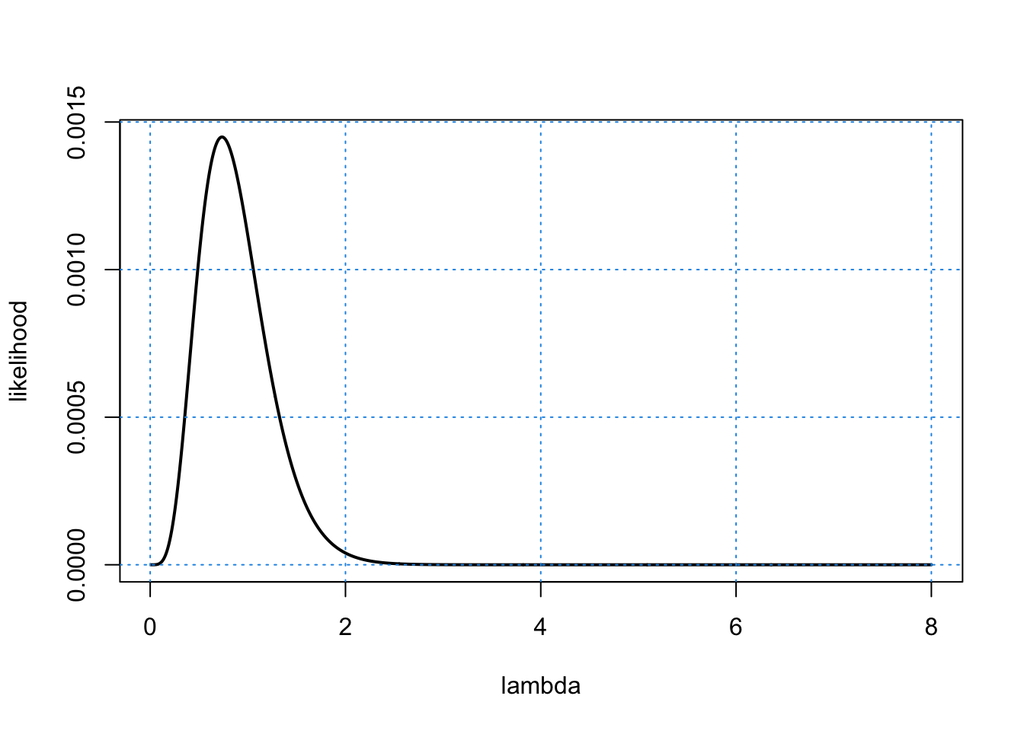

```r
# which t has the maximum likelihood
# t = lambda

t = seq(.01, 8, by = .01)
Y.2 <- sapply(t,function(t){mylikeli.exp(t,X.2)})

plot(t,Y.2, xlab = 'lambda', ylab = 'likelihood', type = 'l', lwd = 2)
grid(col = 4)
```

```r
t[which.max(Y.2)]
```

```
[1] 0.74
```

```r
(xbar=mean(X.2))
```

```
[1] 1.359778
```

4. Plot the same thing for log likelihood:

```r
set.seed(30)

mylikeli.exp_log = function(lambda, x) {
  length(x)*log(lambda) - lambda*sum(x)
}
```

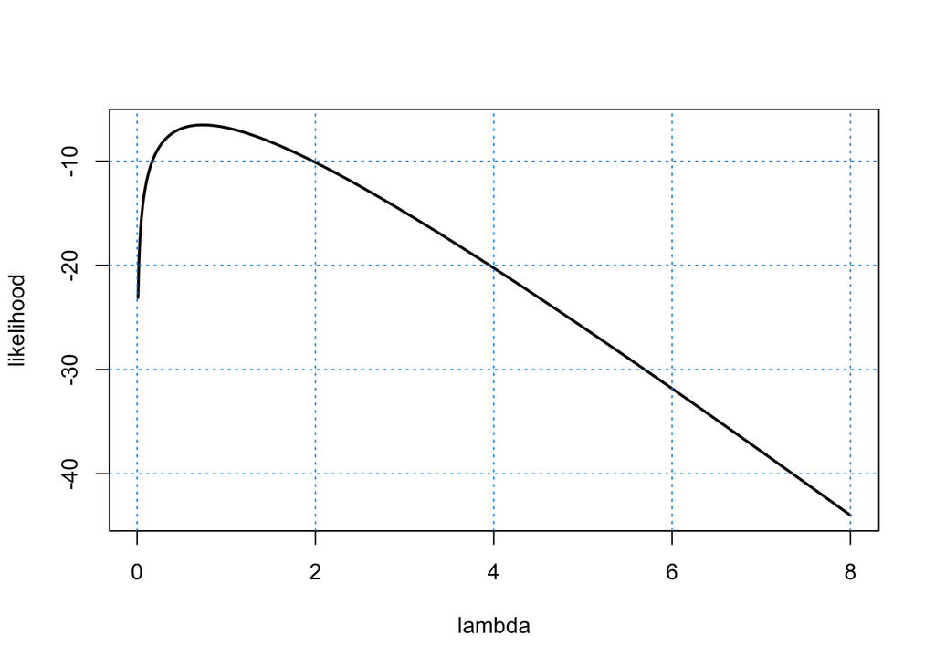

```r
X.3 <- rexp(5)
Y.3 <- sapply(t,function(t){mylikeli.exp_log(t,X.3)})

plot(t,Y.3, xlab = 'lambda', ylab = 'likelihood', type = 'l', lwd = 2)
grid(col = 4)
```

```r
t[which.max(Y.3)]
```

```
[1] 0.74
```

```r
(xbar=mean(X.3))
```

```
[1] 1.359778
```

5. Repeat this 10 times
- 10 random samples with the same lambda
- plot each log-likelihood in the same plot
- what can you say about log likelihoods according to the plot? Does it have to do with the sample size we chose?

Likelihood

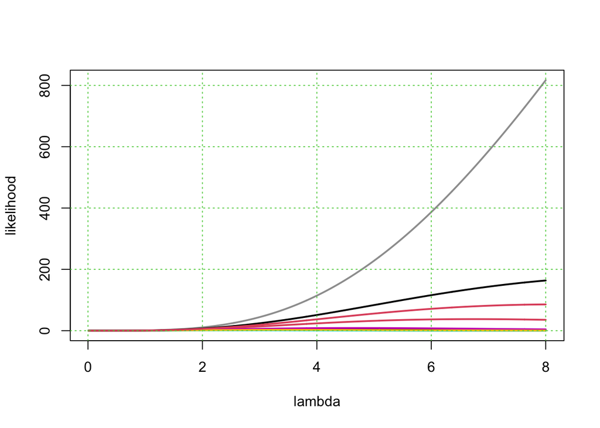

```r
# likelihood
X.0 <- matrix(rexp(40,4), nrow = 4)
likeli.0 <- matrix(NA, nrow = dim(X.0)[2], ncol = length(t))

for (j in 1:ncol(X.0)) {
  X.2 <- X.0[,j]
  likeli.0[j,] <- sapply(t,function(t){mylikeli.exp(t,X.2)})
}

plot(t,likeli.0[1,], xlab = 'lambda', ylab = 'likelihood', type = 'l', lwd = 2, col = 1, ylim = c(0,max(likeli.0)))

for (j in 2:10){
   lines(t,likeli.0[j,], lwd = 2, col = j)
}

grid(col = 3)
```

Log-Likelihood Plot

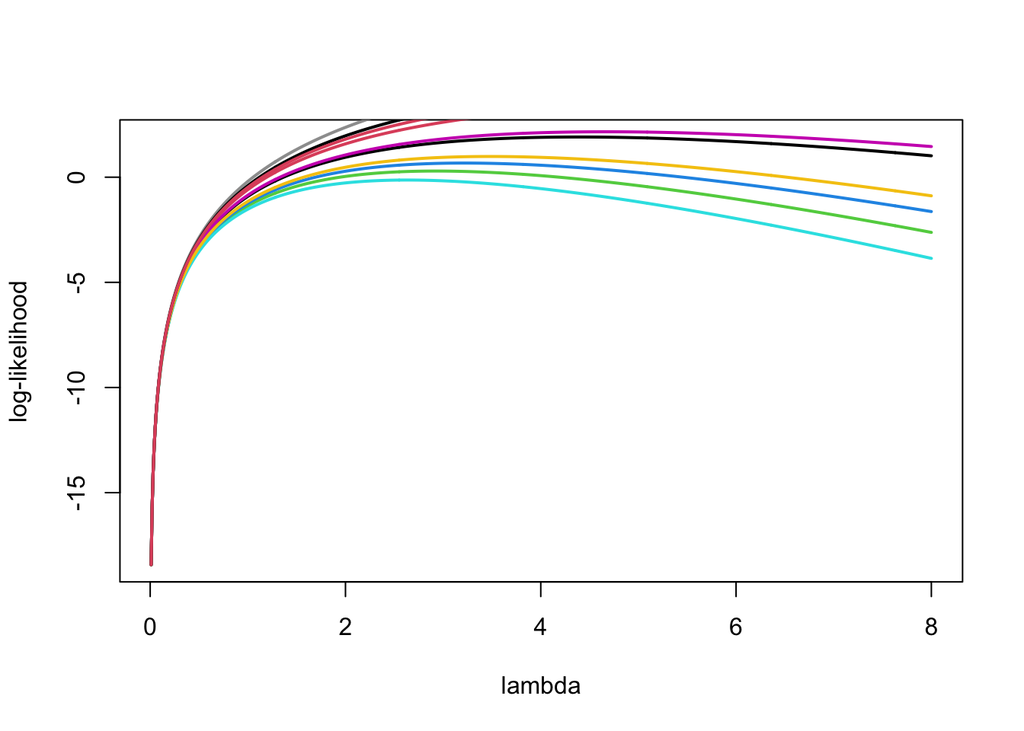

```r
# log-likelihood
plot(t,log(likeli.0[1,]), xlab = 'lambda', ylab = 'log-likelihood', type = 'l', lwd = 2, col = 1)
for (j in 2:10){
 lines(t,log(likeli.0[j,]), lwd = 2, col = j)
}
```

- what can you say about log likelihoods according to the plot? Does it have to do with the sample size we chose?

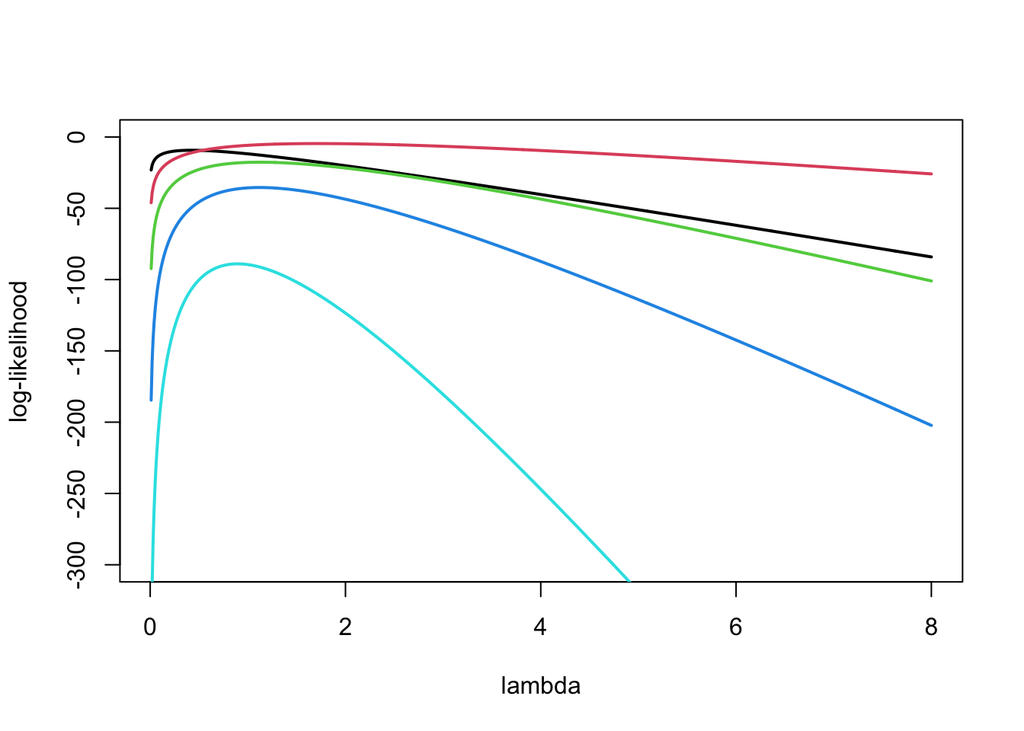

```r
mysize = c(5,10,20,40, 80)
likeli.1 <- matrix(NA, nrow = length(mysize), ncol = length(t))
for (j in 1:length(mysize)){
   mysample <- rexp(mysize[j])
   likeli.1[j,]  <- sapply(t,function(t){mylikeli.exp(t,mysample)})
}

plot(t,log(likeli.1[1,]), xlab = 'lambda', ylab = 'log-likelihood',
        type = 'l', lwd = 2, col = 1, ylim = c(-300,0))
for (j in 2:length(mysize)){
  lines(t,log(likeli.1[j,]), lwd = 2, col = j)
}
```

# Problem-3: Optional

`Don't need to submit anything for this one`

Consider the probability distribution with density
$$f(x|\theta) = \begin{cases}
\theta x^{\theta - 1} \quad (0 \le x \le 1) \\
0 \quad \text{otherwise}
\end{cases}$$
where $\theta > 0$ is unknown.

Find a formula for the method-of-moments estimate for $\theta$.